# Reproducible Research: Peer Assessment 1

### Loading and preprocessing the data

Load data “Activity Monotorting Data” of the file “activity.zip”. The variables includes in this dataset are:

- steps: Number of steps taking in a 5-minute interval
- date: The date on which the measurement was taken in YYYY-MM-DD format
- interval:: Identifier for the 5-minute interval in which measurement was taken

The dataset is stored in a comma-separated-value (CSV) file and there are a total of 17,568 observations in this dataset. Unzip file, for extract file “csv”

```r
unzip ("activity.zip")
```

Load the data with function “read.csv()”, these are stored in variable *data*, convert data in row “date” into Date

```r
data      <- read.csv(file = "activity.csv", sep = ",", header = TRUE,
                      colClasses = c("numeric", "character", "numeric"))
data$date <- as.Date(data$date,format = "%Y-%M-%d")
```

Print data

```r
str(data)
```

```
## 'data.frame':    17568 obs. of  3 variables:
##  $ steps   : num  NA NA NA NA NA NA NA NA NA NA ...
##  $ date    : Date, format: "2012-12-01" "2012-12-01" ...
##  $ interval: num  0 5 10 15 20 25 30 35 40 45 ...
```

### What is mean total number of steps taken per day?

We generate a data.frame with the sum of steps for each date.

```r
steps_day <- tapply(data$steps, data$date, sum,na.rm =TRUE,simplify =  FALSE)
steps_day <- data.frame(matrix(unlist(steps_day),
                                   nrow=length(steps_day), byrow=T))

names(steps_day) <- "steps"
steps_day$date   <- unique(data$date)
```

Print steps_day

```r
head(steps_day)
```

```
##   steps       date
## 1     0 2012-12-01
## 2 10726 2012-12-02
## 3 21923 2012-12-03
## 4 12116 2012-12-04
## 5 23733 2012-12-05
## 6 23754 2012-12-06
```

1. Histogram of the total number of steps taken each day, we will load the library ggplot2

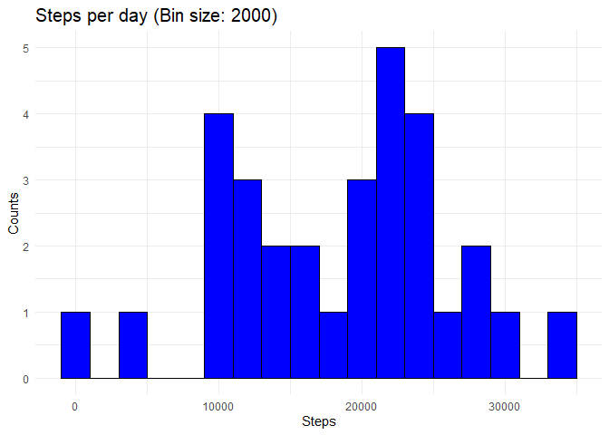

```r
library(ggplot2)

ggplot(steps_day, aes(x=steps)) +
        geom_histogram(binwidth = 2000,color="black", fill="blue")+
        ggtitle("Steps per day (Bin size: 2000)") +
        labs(x = "Steps", y = "Counts")+
        theme_minimal() +
        theme(
           plot.title = element_text(size=15)
        )
```

2. Mean and median total number of steps taken per day

```r
sprintf("Mean: %.3f" ,mean(steps_day$steps), digits = 3)
```

```
## [1] "Mean: 18406.710"
```

```r
sprintf("Median : %i" ,median(steps_day$steps), digits = 3)
```

```
## [1] "Median : 20525"
```

### What is the average daily activity pattern?

```r
steps_interval <- tapply(data$steps, data$interval, mean,na.rm =TRUE,simplify =  FALSE)
steps_interval <- data.frame(matrix(unlist(steps_interval),
                                   nrow=length(steps_interval), byrow=T))

names(steps_interval) <- "steps"
steps_interval$interval   <- unique(data$interval)
```

1. Time series plot of the 5-minute interval and the average number of steps taken, averaged across all days

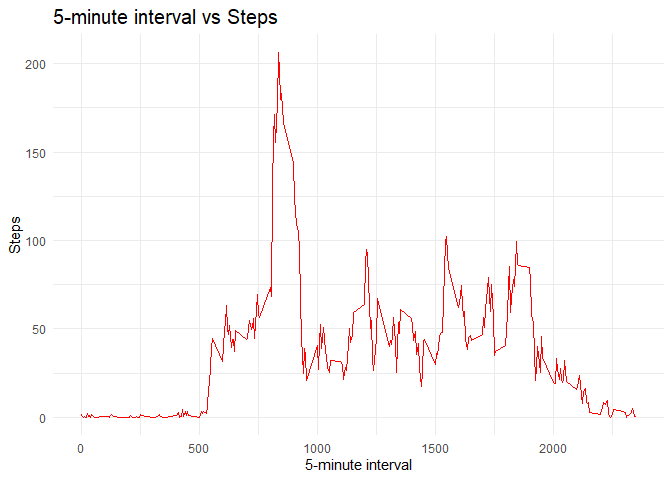

```r
ggplot(data = steps_interval, aes(x = interval, y = steps))+
        geom_line(color = "red")+
        ggtitle("5-minute interval vs Steps") +
        labs(x = "5-minute interval", y = "Steps")+
        theme_minimal() +
        theme(
           plot.title = element_text(size=15)
        )
```

2. Interval from 5-minute intervals, on average across all the days in the dataset, contains the maximum number of steps:

```r
sprintf("Interval: %i",steps_interval$interval[which.max(steps_interval$steps)])
```

```
## [1] "Interval: 835"
```

### Imputing missing values

Total number of missing values in the data set

```r
sprintf("Missing Values: %i" ,sum(is.na(data$steps
                                    )))
```

```
## [1] "Missing Values: 2304"
```

We only have missing values in steps, we are going to replace the missing values by the average of the intervals

```r
new_data         <- data
pos_na           <- is.na(data$steps)
value_intervals  <- data$interval[pos_na]
pos_intervals    <- match(value_intervals,steps_interval$interval)
new_values       <- round(steps_interval$steps[pos_intervals])

new_data$steps[which(pos_na %in%  TRUE)] <- new_values
```

A histogram was made with the new data

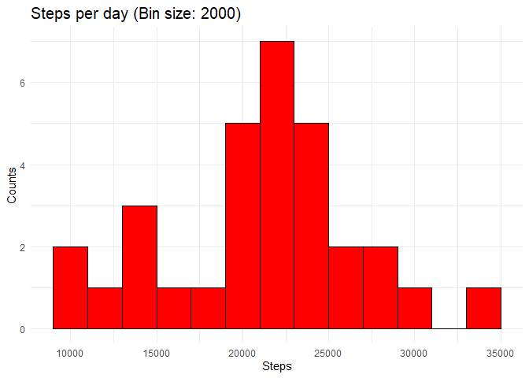

```r
steps_day_2 <- tapply(new_data$steps, new_data$date, sum,na.rm =TRUE,simplify =  FALSE)
steps_day_2 <- data.frame(matrix(unlist(steps_day_2),
                                   nrow=length(steps_day_2), byrow=T))

names(steps_day_2) <- "steps"
steps_day_2$date   <- unique(new_data$date)

# Histogram

ggplot(steps_day_2, aes(x=steps)) +
        geom_histogram(binwidth = 2000,color="black", fill="red")+
        ggtitle("Steps per day (Bin size: 2000)") +
        labs(x = "Steps", y = "Counts")+
        theme_minimal() +
        theme(
           plot.title = element_text(size=15)
        )
```

Mean and median total number of steps taken per day by new data

```r
sprintf("Mean: %.3f" ,mean(steps_day_2$steps), digits = 3)
```

```
## [1] "Mean: 21184.000"
```

```r
sprintf("Median : %i" ,median(steps_day_2$steps), digits = 3)
```

```
## [1] "Median : 21641"
```

Do these values differ from the estimates from the first part of the assignment?

- Values differ.

What is the impact of imputing missing data on the estimates of the total daily number of steps?

- The values change when incorporating new values, which could alter what we want to evaluate if we do not do it correctly.

### Are there differences in activity patterns between weekdays and weekends?

1. We add a new variable “days” to the data.frame “new_data”, to be able to differentiate the days between week and weekend

```r
days     <- weekdays(new_data$date)
ind_days <- days == "Saturday" | days == "Sunday"

days[ind_days]  <- "weekend"
days[!ind_days] <- "weekday"

new_data$days  <- days
```

2. Make a panel plot containing a time series plot

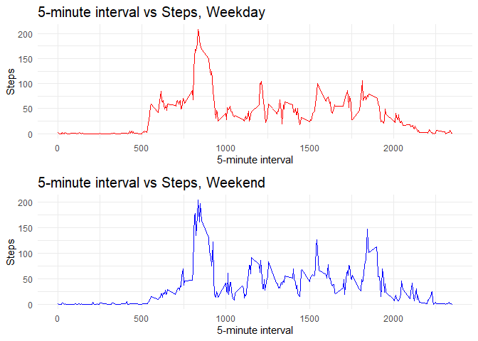

```r
# Data weekday
data_weekday <- subset(new_data, days =="weekday" )

steps_interval_weekday <- tapply(data_weekday$steps, data_weekday$interval,
                                 mean,na.rm =TRUE,simplify =  FALSE)
steps_interval_weekday <- data.frame(matrix(unlist(steps_interval_weekday),
                                   nrow=length(steps_interval_weekday), byrow=T))

names(steps_interval_weekday) <- "steps"
steps_interval_weekday$interval   <- unique(new_data$interval)

# Data weekend
data_weekend <- subset(new_data, days =="weekend" )

steps_interval_weekend <- tapply(data_weekend$steps, data_weekend$interval,
                                 mean,na.rm =TRUE,simplify =  FALSE)
steps_interval_weekend <- data.frame(matrix(unlist(steps_interval_weekend),
                                   nrow=length(steps_interval_weekend), byrow=T))

names(steps_interval_weekend) <- "steps"
steps_interval_weekend$interval   <- unique(new_data$interval)


library(gridExtra)
# Plot
p1 <- ggplot(steps_interval_weekday, aes(x = interval, y = steps))+
        geom_line(color = "red")+
        ggtitle("5-minute interval vs Steps, Weekday") +
        labs(x = "5-minute interval", y = "Steps")+
        theme_minimal() +
        theme(
           plot.title = element_text(size=15)
        )
p2 <- ggplot(steps_interval_weekend, aes(x = interval, y = steps))+
        geom_line(color = "blue")+
        ggtitle("5-minute interval vs Steps, Weekend") +
        labs(x = "5-minute interval", y = "Steps")+
        theme_minimal() +
        theme(
           plot.title = element_text(size=15)
        )
grid.arrange(p1, p2, nrow = 2)
```